# Multidimensional_Arcpy_API

```python
import arcpy
import json
import numpy as np
```

## 1. Open raster dataset as MDim Raster

currently support netcdf, mdim CRF and multidimensional mosaic dataset as input

#### Properties

```
* isMultidimensional
* mdinfo
* slices
* variables
* variableNames
```

#### Methods

```
* getVariableAttributes(variable_name)
* getDimensionNames(variable_name)
* getDimensionAttributes(variable_name, dimension_name)
* getDimensionValues(variable_name, dimension_name)
* save({name})
```

```python
in_raster_path = r"\\pa\raster\DataSwap\Kaixi\compression_data\hycom_glb_regp01.nc"
# load the raster dataset as a mdim raster
myRaster=arcpy.Raster(in_raster_path, True)
myRaster.variables
```

```
['salinity(StdTime=57, StdZ=40)',
 'surf_el(StdTime=57)',
 'water_temp(StdTime=57, StdZ=40)',
 'water_u(StdTime=57, StdZ=40)',
 'water_v(StdTime=57, StdZ=40)']
```

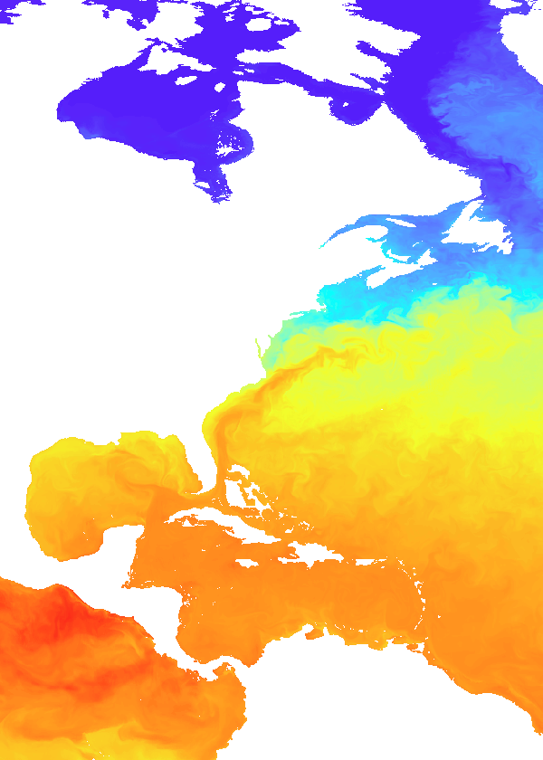

```python
out_raster7 = arcpy.ia.Subset(myRaster, variables = 'water_temp', dimension_definitions = {'stdTime': '2013-05-17T00:00:00', 'stdZ':0})
out_raster7
```

```python
# check whether it is multidimensional
myRaster.isMultidimensional
```

```
True
```

```python
# list the variables
myRaster.variables
```

```
['salinity(StdTime=57, StdZ=40)',
 'surf_el(StdTime=57)',
 'water_temp(StdTime=57, StdZ=40)',
 'water_u(StdTime=57, StdZ=40)',
 'water_v(StdTime=57, StdZ=40)']
```

```python
# check the dimension attribute
myRaster.getDimensionAttributes('salinity', 'StdTime')
```

```
{'HasRanges': False,
 'Minimum': '2013-05-17T00:00:00+00:00',
 'Maximum': '2013-05-24T00:00:00+00:00',
 'Interval': 3.0,
 'IntervalUnit': 'Hours',
 'HasRegularIntervals': True,
 'Unit': 'ISO8601'}
```

```python
# check the dimension values
myRaster.getDimensionValues('salinity', 'StdTime')
```

```
['2013-05-17T00:00:00+00:00',
 '2013-05-17T03:00:00+00:00',
 '2013-05-17T06:00:00+00:00',
 '2013-05-17T09:00:00+00:00',
 '2013-05-17T12:00:00+00:00',
 '2013-05-17T15:00:00+00:00',
 '2013-05-17T18:00:00+00:00',
 '2013-05-17T21:00:00+00:00',
 '2013-05-18T00:00:00+00:00',
 '2013-05-18T03:00:00+00:00',
 '2013-05-18T06:00:00+00:00',
 '2013-05-18T09:00:00+00:00',
 '2013-05-18T12:00:00+00:00',
 '2013-05-18T15:00:00+00:00',
 '2013-05-18T18:00:00+00:00',
 '2013-05-18T21:00:00+00:00',
 '2013-05-19T00:00:00+00:00',
 '2013-05-19T03:00:00+00:00',
 '2013-05-19T06:00:00+00:00',
 '2013-05-19T09:00:00+00:00',
 '2013-05-19T12:00:00+00:00',
 '2013-05-19T15:00:00+00:00',
 '2013-05-19T18:00:00+00:00',
 '2013-05-19T21:00:00+00:00',
 '2013-05-20T00:00:00+00:00',
 '2013-05-20T03:00:00+00:00',
 '2013-05-20T06:00:00+00:00',
 '2013-05-20T09:00:00+00:00',
 '2013-05-20T12:00:00+00:00',
 '2013-05-20T15:00:00+00:00',
 '2013-05-20T18:00:00+00:00',
 '2013-05-20T21:00:00+00:00',
 '2013-05-21T00:00:00+00:00',
 '2013-05-21T03:00:00+00:00',
 '2013-05-21T06:00:00+00:00',
 '2013-05-21T09:00:00+00:00',
 '2013-05-21T12:00:00+00:00',
 '2013-05-21T15:00:00+00:00',
 '2013-05-21T18:00:00+00:00',
 '2013-05-21T21:00:00+00:00',
 '2013-05-22T00:00:00+00:00',
 '2013-05-22T03:00:00+00:00',
 '2013-05-22T06:00:00+00:00',
 '2013-05-22T09:00:00+00:00',
 '2013-05-22T12:00:00+00:00',
 '2013-05-22T15:00:00+00:00',
 '2013-05-22T18:00:00+00:00',
 '2013-05-22T21:00:00+00:00',
 '2013-05-23T00:00:00+00:00',
 '2013-05-23T03:00:00+00:00',
 '2013-05-23T06:00:00+00:00',
 '2013-05-23T09:00:00+00:00',
 '2013-05-23T12:00:00+00:00',
 '2013-05-23T15:00:00+00:00',
 '2013-05-23T18:00:00+00:00',
 '2013-05-23T21:00:00+00:00',
 '2013-05-24T00:00:00+00:00']
```

## 2. new functions in arcpy.ia

- Subset
- Aggregate
- Apply

### 2.1. Subset(in_raster, {variables}, {dimension_definitions})

https://pro.arcgis.com/en/pro-app/arcpy/image-analyst/subset.htm

Filter the mdim raster along variables or/and dimensions.  
The paramter **variables** supports single variable name or a list of variable names

- varialbes = varaible_name
- variables = [variable_name,...]

The parameter **dimension_definitions** support dict input as below

- {dimension_name: value, ...}
- {dimension_name: (min, max),...}
- {dimension_name:[value1, (min1, max1), …], ...}
- {dimension_name:(from, to, recurrent_interval_size, recurrent_interval_unit), ...}
  - recurrently select single slice if to = None
  - otherwise, it means recurrently select ranges

#### Case 1. filter variables only

```python
# select all slices of the two variables surface elevation and water temperature
out_raster1 = arcpy.ia.Subset(myRaster, variables = ['surf_el', 'water_temp'])
out_raster1.variables
```

```
['surf_el(StdTime=57)', 'water_temp(StdTime=57, StdZ=40)']
```

#### Case 2. filter dimensions: {dimension_name: value, ...}

```python
# filter those variables that have dimension depth, only choose their slice(s) at depth=0.
# For those variables that do not have dimension depth, all slices would be selected
out_raster2 = arcpy.ia.Subset(myRaster, dimension_definitions = {'StdZ':0})
# verify the depth values in the variabiable are zero or not
out_raster2.getDimensionValues('salinity', 'StdZ')
```

```
[0.0]
```

#### Case 3. filter dimensions: {dimension_name: (min, max), ...}

```python
# only interested in the day 2013/05/18
out_raster3 = arcpy.ia.Subset(myRaster, dimension_definitions = {'StdTime': ('2013-05-18T00:00:00', '2013-05-18T23:59:59')})
# verify the time values in the variables
out_raster3.getDimensionValues('surf_el', 'StdTime')
```

```
['2013-05-18T00:00:00+00:00',
 '2013-05-18T03:00:00+00:00',
 '2013-05-18T06:00:00+00:00',
 '2013-05-18T09:00:00+00:00',
 '2013-05-18T12:00:00+00:00',
 '2013-05-18T15:00:00+00:00',
 '2013-05-18T18:00:00+00:00',
 '2013-05-18T21:00:00+00:00']
```

#### Case 4. filter dimensions: {dimension_name: [value1, (min1, max1),...], ...}

```python
# only interested in the day 2013/05/18
out_raster4 = arcpy.ia.Subset(myRaster, dimension_definitions = {'stdZ':[(-10, 0), (-500, -100), -1000]})
# verify the depth values in the varialbes
out_raster4.getDimensionValues('salinity', 'StdZ')
```

```
[-1000.0,
 -500.0,
 -400.0,
 -350.0,
 -300.0,
 -250.0,
 -200.0,
 -150.0,
 -125.0,
 -100.0,
 -10.0,
 -8.0,
 -6.0,
 -4.0,
 -2.0,
 0.0]
```

#### Case 5. filter dimensions: {dimension_name: (from, to, recurrent_interval_size, recurrent_interval_unit),...}

```python
# only interested in data acquired no later than 3am each day
out_raster5 = arcpy.ia.Subset(myRaster, dimension_definitions = {'stdTime': ('2013-05-17T00:00:00', '2013-05-17T03:00:00', 1, 'day')})
# verify the time values in the varialbes
out_raster5.getDimensionValues('surf_el', 'StdTime')
```

```
['2013-05-17T00:00:00+00:00',
 '2013-05-17T03:00:00+00:00',
 '2013-05-18T00:00:00+00:00',
 '2013-05-18T03:00:00+00:00',
 '2013-05-19T00:00:00+00:00',
 '2013-05-19T03:00:00+00:00',
 '2013-05-20T00:00:00+00:00',
 '2013-05-20T03:00:00+00:00',
 '2013-05-21T00:00:00+00:00',
 '2013-05-21T03:00:00+00:00',
 '2013-05-22T00:00:00+00:00',
 '2013-05-22T03:00:00+00:00',
 '2013-05-23T00:00:00+00:00',
 '2013-05-23T03:00:00+00:00',
 '2013-05-24T00:00:00+00:00']
```

```python
# only interested in data acquired at noon
out_raster6 = arcpy.ia.Subset(myRaster, dimension_definitions = {'stdTime': ('2013-05-17T12:00:00', None, 1, 'day')})
# verify the time values
out_raster6.getDimensionValues('surf_el', 'StdTime')
```

```
['2013-05-17T12:00:00+00:00',
 '2013-05-18T12:00:00+00:00',
 '2013-05-19T12:00:00+00:00',
 '2013-05-20T12:00:00+00:00',
 '2013-05-21T12:00:00+00:00',
 '2013-05-22T12:00:00+00:00',
 '2013-05-23T12:00:00+00:00']
```

#### Case 6. combinations of variable and dimensions filters

```python
# intereted in water temperature at surface level on 2013/05/17
out_raster7 = arcpy.ia.Subset(myRaster, variables = 'water_temp', dimension_definitions = {'stdTime': ('2013-05-17T00:00:00', '2013-05-17T23:59:59'), 'stdZ':0})
out_raster7.variables
```

```
['water_temp(StdTime=8, StdZ=1)']
```

### 2.2. Aggregate(in_raster, dimension_name, raster_function, {raster_function_arguments}, {aggregation_definition})

https://pro.arcgis.com/en/pro-app/arcpy/image-analyst/aggregate.htm

Aggregate mdim raster based on user specified dimension intervals and aggregation method  
The paramter aggregation_def defines how slices are grouped

- {"interval": interval_keyword}
  - interval_keyword includes hourly, daily, weekly, monthly, yearly
- {"interval_value": value, "interval_unit": unit}
- {"interval_ranges": [(min,max),(min,max), ...]}
- {"recurrent_interval": recurrent_keyword}
  - recurrent_keyword includes quarterly, monthly, weekly, daily

```python
arcpy.CheckOutExtension("ImageAnalyst")
```

[output not shown]

```python
in_raster_path = r"\\pa\raster\dataswap\kaixi\compression_data\prcp_1980.nc"
# load the raster dataset as a mdim raster
prcpRaster=arcpy.Raster(in_raster_path, True)
prcpRaster.variables
```

```
['prcp(StdTime=365)']
```

#### Case 1. aggregate along the whole dimension ranges

```python
# calc the average precipitation in 1980
avg_prcp = arcpy.ia.Aggregate(prcpRaster, 'StdTime', 'Mean')
avg_prcp.variables
```

```
['prcp(StdTime=1)']
```

```python
# calc the average monthly precipitation in 1980
monthly_avg_prcp = arcpy.ia.Aggregate(prcpRaster, 'StdTime', 'Mean', aggregation_definition = {"recurrent_interval":'monthly'})
monthly_avg_prcp.variables
```

```
['prcp(StdTime=12)']
```

#### Visualization

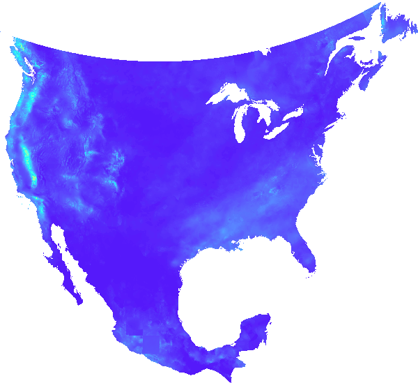

```python
monthly_avg_prcp
```

#### Case 3. aggregation_definition = {"interval_value" = value, "interval_unit": unit}

```python
# calc the average precipitation within every 15 days in 1980
avg_prcp_every_15days = arcpy.ia.Aggregate(prcpRaster, 'StdTime', 'Mean', aggregation_definition = {"interval_value": 15, "interval_unit":'day'})
avg_prcp_every_15days.variables
```

```
['prcp(StdTime=25)']
```

#### Case 4. aggregation_definition = {"interval_ranges": [(min,max),(min,max), ...]}

```python
# calc the average precipitation within each customized range
avg_prcp_within_customzied_ranges = arcpy.ia.Aggregate(prcpRaster, 'StdTime', 'Mean', {"interval_ranges" :[("1980-01-01T12:00:00", "1980-01-31T12:00:00"), ("1980-05-01T12:00:00", "1980-05-31T12:00:00")]})
avg_prcp_within_customzied_ranges.variables
```

[output not shown]

```python
arcpy.CheckInExtension("ImageAnalyst")
```

```
'CheckedIn'
```

### 2.3. Apply(in_raster, raster_function, {raster_function_arguments})

https://pro.arcgis.com/en/pro-app/arcpy/image-analyst/apply.htm

apply a builtin raster function or customized python raster function, or function chain to single raster or several rasters. It works with multidimensional as well as non-multidimensional raster(s)  
the parameter in_raster has 4 different fomats

- single raster
  - for those functions that need one raster input, e.g., NDVI
- (raster1, raster2)
  - for those functions that have 2 raster inputs: Raster and Raster2, e.g., Arithmetic
- [raster1, raster2, …]
  - for those functions that need an array of raster inputs: Rasters, e.g.,CompositeBand
- {var_name1: raster1, var_name2: raster2, …}
  - for those functions that need a set of named raster inputs, e.g., HeatIndex

the paramter raster_function could be a built-in raster function name or a function template (.rft.xml)

#### Case 1. in_raster = raster

```python
# load a multi-band raster dataset
in_raster1 = arcpy.Raster(r"\\pa\raster\DataSwap\Kaixi\Landsat\Input_LandsatImage.tif")
# calc NDVI
out_ndvi_raster = arcpy.ia.Apply(in_raster1, 'NDVI', {'VisibleBandID':3,'InfraredBandID':4, 'ScientificOutput': True})
```

#### Visualization

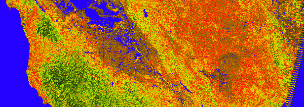

```python
rendered_ndvi_raster = arcpy.ia.Render(out_ndvi_raster, rendering_rule = {"min": 0, "max": 0.9}, colormap = "NDVI")
rendered_ndvi_raster
```

#### Case 2. in_raster = (raster1, raster2)

```python
# add the raster
out_Arithmetic_raster = arcpy.ia.Apply((out_ndvi_raster, 2), r'\\pa\raster\dataswap\kaixi\mdim_output\Arithmetic.rft.xml')
```

#### Case 3. in_raster = [raster1, raster2, …]

```python
folder = r"\\pa\raster\DataSwap\Kaixi\toGao\Landsat7\x10y35\2000\ls7_gm_nbart_10_-35_20000101_"
in_raster1 = folder+"blue.tif"
in_raster2 = folder+"green.tif"
in_raster3 = folder+"red.tif"
out_composite_raster = arcpy.ia.Apply([in_raster1, in_raster2, in_raster3], 'CompositeBand')
# check band count
out_composite_raster.bandCount
```

```
3
```

#### Case 4. in_raster = {var_name1: raster1, var_name2: raster2, …}

```python
# load the grib file as a multidimensional raster
temp = arcpy.Raster(r"C:\DemoData\analysis\ds.temp.bin", True)

# load the grib file as a mdim raster
rh = arcpy.Raster(r"C:\DemoData\analysis\ds.rhm.bin", True)
```

```python
# apply heatindex function to two mdim raster, the output is a mdim raster ,each slice is the heat_index at a certain time point
heat_index_raster= arcpy.ia.Apply({'temperature': temp, 'rh': rh}, 'HeatIndex', {'units':'Kelvin', 'outUnits':'Fahrenheit', 'matchVariable': 0})
heat_index_raster.variables # the variable name changed to *
```

```
['*(StdTime=18)']
```